[figure not shown]

Research report  
Vigil · Horizon

# Vigil vs Horizon: a comparison and an improvement plan

SafeCircle child-safety risk classifiers, state of the evidence on 2026-10-01

SafeCircle research

2026-10-01

# 1 Summary

**Vigil** and **Horizon** are two answers to the same product question: given a chat between a child and someone else, which of seven risks (grooming, bullying, sexual content, isolation, personal info, platform migration, threats) does it show, and how severe is it? They answer it with very different machinery.

Vigil

+30 pts

more risky chats caught, correct category (Qwen3-8B set)

Vigil

3.6x faster

median latency on the same 8-CPU node

Horizon

17% smaller

on disk (INT8 against Vigil fp32)

Neither

12-21%

benign chats flagged on unseen text; the target is 2%

|  | **Horizon** | **Vigil** |
| --- | --- | --- |
| Base model | Gemma 3 1B (mobile) / Llama 3.2 3B (server), decoder LLM | Laya-multilingual, 322M encoder (mmBERT-base) |
| How it answers | generates a JSON string token by token | one forward pass, typed scores per category |
| Adaptation | QLoRA fine-tune | full fine-tune plus a calibration step |
| Output | `risk_level`, `categories`, `confidence` | per-category probability, severity, confidence |
| Thresholds | none (fixed by training) | per-category, chosen on validation data |
| Maturity | shipped on-device export (LiteRT-LM) | research; no phone measurement yet |

**What the evidence says**, on identical chats, one metric implementation, and one 8-CPU node:

1. **Vigil catches more risky chats with the correct category on every test set**, by 4.4 points on Horizon’s own sample and by 21.7 and 30.4 points on chats written by two models neither system trained on.
2. **Vigil is about 3.6 times faster on CPU** (207 ms against 747 ms median per chat) and uses less memory (2,018 against 2,601 MiB), because it reads the chat once and does not generate text.
3. **Horizon is smaller on disk** (1,017 against 1,231 MiB) and has the better false-alarm rate on its own sample (0.4% against 0.9%).
4. **Neither is good enough on unseen text.** Both flag 12-21% of harmless chats from the held-out generators. The 2% target is missed by every system on both sets.
5. **Everything is measured on LLM-written text.** Nothing here shows real-world performance, and nothing here was run on a phone.

The rest of this document lays out the design differences, the benchmark in detail, how Vigil got to its current state, where each system is weak, and a prioritised list of improvements for both.

# 2 Design comparison

## 2.1 Architecture

Table 1. Architecture and tooling.

| Aspect | Horizon | Vigil |
| --- | --- | --- |
| Model family | Decoder-only LLM (Gemma 3 1B mobile build; Llama 3.2 3B server build) | Bidirectional encoder (mmBERT-base inside Laya-multilingual) |
| Parameters | ~1B (mobile) / ~3B (server) | 322M |
| Context window | 1,280 tokens (`ekv1280` export) | 1,024 tokens; overflow is flagged, never truncated silently |
| Inference style | Autoregressive generation of a JSON answer | Typed decisions in a single pass: `noul` (yes/no per category), `score` (severity), `choice` |
| Free text possible | Yes, so the model can continue the chat or emit malformed JSON | No: it only produces numbers, so output cannot be malformed |
| Multi-label | Native (`categories` list) | Native in the 8-question design; the 2-pass design shares one softmax across categories |
| Fine-tuning | QLoRA (LoRA rank 128-256 on the server configs) | Full fine-tune, cross-entropy plus RLCD term; temperatures fitted on a held-out slice |
| Threshold policy | None. Operating point is whatever training produced | Per-category thresholds under a 2% benign false-alarm budget on validation data |
| Export | LiteRT-LM INT8 (Android, iOS), GGUF | ONNX (parity with PyTorch verified); Core ML planned |
| Licence | SafeCircle internal | Apache-2.0 (base Laya and Vigil) |

Vigil’s two question designs:

- **8-question (`noul7`)**: seven yes/no questions plus severity = 8 encoder passes per chat. Closest to the original spec and the most stable, but about 3x slower on CPU.
- **2-pass (`choice8`)**: one 8-way choice (benign plus 7 categories) plus severity = 2 passes. This is the design benchmarked against Horizon below. It is cheaper, but its softmax makes categories compete, and its multi-label path is untested because the training data has at most one category per chat.

## 2.2 What each side offers beyond the model

Vigil’s design spec (§10) lists what it deliberately does *not* have. Horizon has these; Vigil does not:

- regex rule pre-filter and adaptive tiers,
- a TUI and remote SLURM tooling,
- mobile benchmarking and profiling scripts,
- a published data-generation pipeline (500K conversations, 8 categories, 60% English / 40% Spanish),
- two shipped mobile sizes (INT8 about 1.2 GB, INT4 about 0.7 GB),
- a refusal behaviour for off-task prompts (`{"error": ...}`).

Vigil’s own additions are the evaluation discipline: Wilson intervals, held-out generators, seed variance, a false-alarm budget rule, and an offline calibration experiment. Horizon’s recorded results carry none of these.

# 3 Evaluation setup

The comparison in this document uses the head-to-head benchmark run on one exclusive cluster node on 2026-09-30.

Table 2. Test sets (all LLM-written; none are real conversations).

| Set | Rows | Benign | Written by | Seen in training? |
| --- | --- | --- | --- | --- |
| Horizon sample | 2,000 | 267 | Horizon’s generators (mostly Qwen2.5-7B, some Claude) | Same distribution as both models’ training data |
| Llama-3.1-8B | 831 | 147 | Llama-3.1-8B-Instruct, fresh prompts | No, for both systems |
| Qwen3-8B | 850 | 150 | Qwen3-8B, same prompts as the Llama set | No, for both (but close to Horizon’s Qwen family) |

**Protocol**

- **Same chats, same metric code.** Both systems are scored by the same code. Horizon outputs categories, so a predicted category counts as probability 1. A risk level with no category counts as a flag (a false alarm on benign rows, never a correct catch). Unparseable output predicts nothing, the same rule as Horizon’s own benchmark.
- **Vigil**: the 2-pass design with educational hard negatives, three training seeds, thresholds from the greedy 2% rule picked on validation data (not on these sets).
- **Horizon**: the deployed INT8 LiteRT-LM export with its own prompt and parser, greedy decoding. Two builds: **focus** (current) and **baseline** (the build behind Horizon’s recorded results).
- **Speed and size**: one exclusive 8-CPU node, GPU unused, 300 chats, wall time with the model loaded.
- **Metrics**: *catch (correct category)* is the share of risky chats where at least one gold category is flagged. *Benign false alarms* is the share of benign chats where anything is flagged. Intervals are 95% Wilson intervals.

# 4 Results

## 4.1 Accuracy

Table 3. Headline accuracy. Vigil counts are summed over 3 seeds (denominators 3x larger), but its intervals are computed from the per-seed mean counts, because the seeds score the same rows.

| Set | System | Catch (correct) | Counts | Benign false alarms | FA counts | Catch (any category) |
| --- | --- | --- | --- | --- | --- | --- |
| Horizon sample | Vigil (2-pass, 3 seeds) | 98.3% (97.5%-98.8%) | 5,109 / 5,199 | 0.9% (0.3%-2.9%) | 7 / 801 | 99.9% |
| Horizon sample | Horizon focus (INT8) | 93.9% (92.7%-95.0%) | 1,628 / 1,733 | 0.4% (0.1%-2.1%) | 1 / 267 | 99.9% |
| Horizon sample | Horizon baseline (INT8) | 92.5% (91.2%-93.6%) | 1,603 / 1,733 | 13.9% (10.2%-18.5%) | 37 / 267 | 99.6% |
| Llama-3.1-8B | Vigil (2-pass, 3 seeds) | 89.4% (86.9%-91.5%) | 1,835 / 2,052 | 11.6% (7.3%-17.7%) | 51 / 441 | 99.3% |
| Llama-3.1-8B | Horizon focus (INT8) | 67.7% (64.1%-71.1%) | 463 / 684 | 21.1% (15.3%-28.4%) | 31 / 147 | 92.0% |
| Llama-3.1-8B | Horizon baseline (INT8) | 65.1% (61.4%-68.5%) | 445 / 684 | 29.3% (22.5%-37.1%) | 43 / 147 | 89.6% |
| Qwen3-8B | Vigil (2-pass, 3 seeds) | 93.0% (90.9%-94.7%) | 1,953 / 2,100 | 17.1% (11.9%-23.9%) | 77 / 450 | 99.4% |
| Qwen3-8B | Horizon focus (INT8) | 62.6% (58.9%-66.1%) | 438 / 700 | 20.0% (14.4%-27.1%) | 30 / 150 | 85.0% |
| Qwen3-8B | Horizon baseline (INT8) | 57.9% (54.2%-61.5%) | 405 / 700 | 20.7% (15.0%-27.8%) | 31 / 150 | 76.3% |

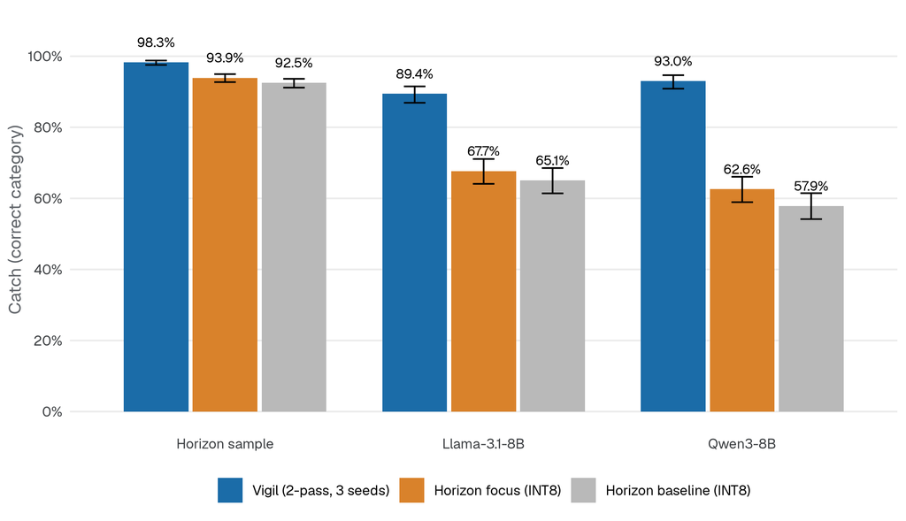

Figure 1. Risky chats caught with the correct category (higher is better). Bars show 95% Wilson intervals.

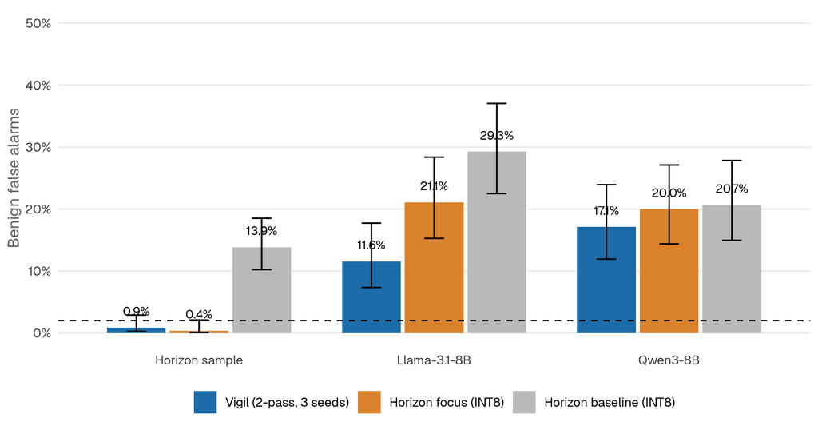

Figure 2. Benign chats wrongly flagged (lower is better). The dashed line is the 2% target.

Reading it:

- **Vigil dominates on recall.** On the unseen sets its interval for catch lies far above Horizon’s (for example Llama: 89.4% against 67.7%, with intervals that do not come close to overlapping).
- **False alarms are a mixed picture.** On Horizon’s own sample Horizon-focus is better (1 of 267 against 7 of 801, so a handful of rows; the intervals overlap). On the unseen sets Vigil’s rate is lower in the point estimate but the intervals overlap with Horizon-focus’s (Llama 11.6% against 21.1%; Qwen3 17.1% against 20.0%). Every system misses the 2% target on unseen text.
- **The two Horizon builds differ mostly in false alarms on its own sample**, where the baseline flags 13.9% of benign chats and focus 0.4%.

### 4.1.1 Is Horizon missing chats, or naming the wrong category?

Table 4. Credit for any flag against credit for the right category.

| Set | System | Catch (any flag) | Catch (correct category) | Gap (points) |
| --- | --- | --- | --- | --- |
| Horizon sample | Vigil (2-pass, 3 seeds) | 99.9% | 98.3% | 1.7 |
| Horizon sample | Horizon focus (INT8) | 99.9% | 93.9% | 5.9 |
| Llama-3.1-8B | Vigil (2-pass, 3 seeds) | 99.3% | 89.4% | 9.9 |
| Llama-3.1-8B | Horizon focus (INT8) | 92.0% | 67.7% | 24.3 |
| Qwen3-8B | Vigil (2-pass, 3 seeds) | 99.4% | 93.0% | 6.4 |
| Qwen3-8B | Horizon focus (INT8) | 85.0% | 62.6% | 22.4 |

The question matters because the benchmark credits Horizon only when it names a gold category. If Horizon is credited with *any* flag, its focus build reaches 99.9% / 92.0% / 85.0%. So much of Horizon’s gap on unseen text is **wrong categories and unparseable output**, not chats it never noticed. Vigil’s any-flag figure is 99.3-99.9%, but that is partly bought with its false-alarm rate (it flags a lot).

Table 5. Horizon outputs that did not parse (rows with no usable answer). None were runtime errors: truncated JSON, malformed keys, runaway numbers, or the model continuing the chat.

| Horizon build | Horizon sample | Llama-3.1-8B | Qwen3-8B |
| --- | --- | --- | --- |
| Horizon focus (INT8) | 9 | 23 | 85 |
| Horizon baseline (INT8) | 18 | 46 | 147 |

Unparseable output grows from 9 rows (0.5%) on Horizon’s own sample to 85 (10%) on Qwen3 for the focus build, and to 147 (17%) for the baseline. Vigil cannot fail this way: its output is numbers.

## 4.2 Per-category recall and precision

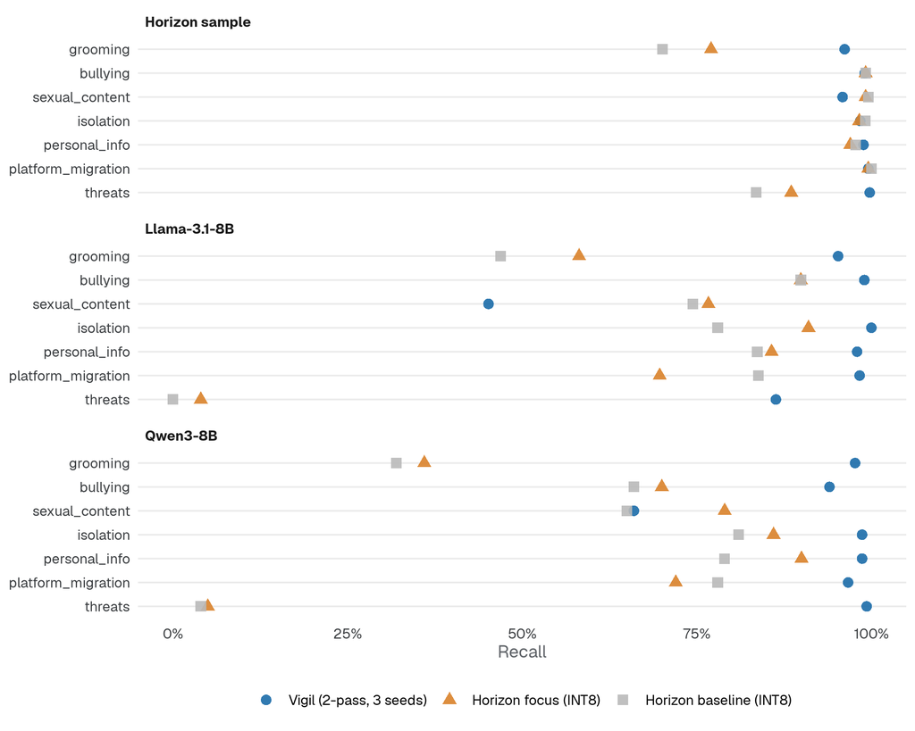

Figure 3. Recall by category and set. `sexual_content` labels on the two unseen sets are weak (see text).

Table 6. Recall / precision per category (Vigil mean of 3 seeds; Horizon focus build).

| Set | Category | Vigil (2-pass, 3 seeds) | Horizon focus (INT8) |
| --- | --- | --- | --- |
| Horizon sample | grooming | 96% / 85% | 77% / 100% |
| Horizon sample | bullying | 99% / 75% | 99% / 96% |
| Horizon sample | sexual_content | 96% / 81% | 99% / 73% |
| Horizon sample | isolation | 98% / 95% | 98% / 98% |
| Horizon sample | personal_info | 99% / 86% | 97% / 100% |
| Horizon sample | platform_migration | 100% / 90% | 100% / 100% |
| Horizon sample | threats | 100% / 80% | 89% / 100% |
| Llama-3.1-8B | grooming | 95% / 55% | 58% / 56% |
| Llama-3.1-8B | bullying | 99% / 47% | 90% / 79% |
| Llama-3.1-8B | sexual_content | 45% / 76% | 77% / 45% |
| Llama-3.1-8B | isolation | 100% / 85% | 91% / 86% |
| Llama-3.1-8B | personal_info | 98% / 66% | 86% / 76% |
| Llama-3.1-8B | platform_migration | 98% / 85% | 70% / 90% |
| Llama-3.1-8B | threats | 86% / 56% | 4% / 80% |
| Qwen3-8B | grooming | 98% / 66% | 36% / 72% |
| Qwen3-8B | bullying | 94% / 47% | 70% / 81% |
| Qwen3-8B | sexual_content | 66% / 67% | 79% / 39% |
| Qwen3-8B | isolation | 99% / 85% | 86% / 80% |
| Qwen3-8B | personal_info | 99% / 72% | 90% / 91% |
| Qwen3-8B | platform_migration | 97% / 81% | 72% / 91% |
| Qwen3-8B | threats | 99% / 46% | 5% / 71% |

The pattern that matters:

- **Threats.** Horizon-focus recall falls from 88.5% on its own sample to **4.0% on Llama and 5.0% on Qwen3**. Vigil holds 86% and 99%. This is the largest single gap in the benchmark, and a worrying one for a category about violence.
- **Grooming.** Horizon-focus recall is 77.0% on its own sample and 58.2% / 36.0% on the unseen sets; Vigil’s is 96.2% / 95.2% / 97.7%. Horizon’s grooming precision is 100% on its own sample (it flags rarely) and that is a different operating point rather than a better model.
- **Platform migration, isolation and personal info.** Horizon is competitive on its own sample and loses 10-30 points on the unseen sets.
- **Bullying and `sexual_content`.** Horizon is as good or better in-distribution. `sexual_content` labels in the Llama and Qwen3 sets are unreliable (the generators softened or refused the request), so read those rows as weak. Vigil’s low `sexual_content` recall on the unseen sets (45-66%) is partly a label problem and partly a real gap; the evidence cannot separate the two.
- **Precision is lower for Vigil on the unseen sets** (for example bullying precision 47% against 80% for Horizon on Llama). It trades precision for recall at its 2% validation budget.

## 4.3 Operating points

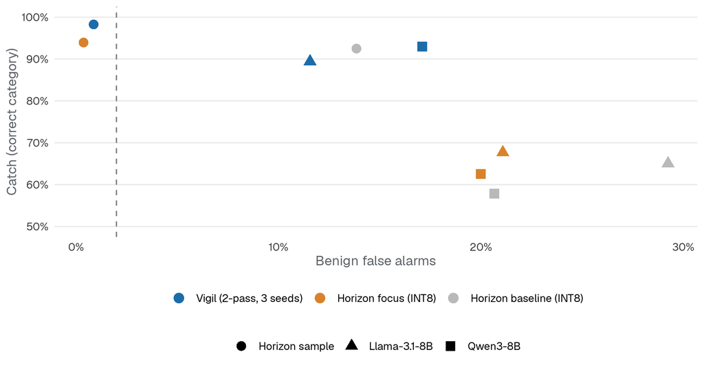

Figure 4. False alarms against catch. Up and to the left is better. Each dot is one system on one set.

On its own sample both systems are in the corner that matters. On unseen text both drift right (more false alarms), but Vigil keeps its height and Horizon loses it. So Vigil’s operating point is better in the sense that it is not dominated anywhere: higher catch at similar or lower false alarms.

## 4.4 Speed, size and memory

Table 7. One 8-CPU node, CPU only, 300 chats, model preloaded.

| System | Format | p50 (ms) | p95 (ms) | On disk (MiB) | Peak memory (MiB) |
| --- | --- | --- | --- | --- | --- |
| Vigil | ONNX fp32 | 207 | 338 | 1,231 | 2,018 |
| Horizon focus | LiteRT-LM INT8 | 747 | 999 | 1,017 | 2,601 |
| Horizon baseline | LiteRT-LM INT8 | 748 | 1052 | 1,017 | 2,601 |

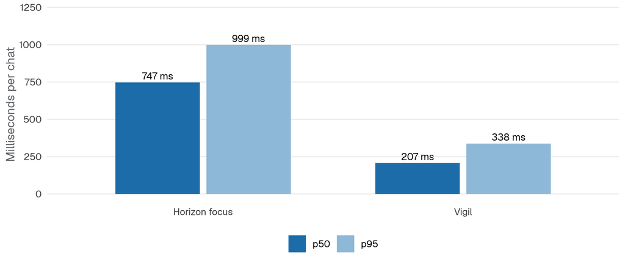

Figure 5. Median and 95th-percentile latency per chat on the same CPU node.

## 4.5 Against the targets in Vigil’s spec

Table 8. Spec targets against measured results.

| Metric | Horizon recorded | Vigil target | Vigil measured | Status |
| --- | --- | --- | --- | --- |
| Grooming recall | 90.36% (issue #8) | >= 97% | 96.2% on Horizon sample, 95.2% Llama, 97.7% Qwen3 (3-seed mean; below 97% on two of three sets) | Close, not proven |
| Catch rate | 12.90% (regex rules only, not a model) | >= 80% | 98.3% / 89.4% / 93.0% (correct category) | Met, on synthetic text |
| Latency on-device | 2.1 s | <= 500 ms | 207 ms p50 on a server CPU; 10.6 ms on a GPU (pilot checkpoint); phones unmeasured | Server met, device unknown |
| Disk | 1,017 MiB | as small as possible | 1,231 MiB fp32; 883 MB dynamic int8 (not useful) | Not met; larger than Horizon |
| Benign false alarms | n/a | 2% (budget) | 0.9% in-distribution; 11.6% / 17.1% unseen | Met in-distribution only |

One caution on the first two rows. Horizon’s 12.90% was its regex pre-filter, not the model, so it is not comparable. And Horizon’s recorded grooming recall of 90.36% was **not reproduced** here: even the baseline build behind that figure scored 70.1% grooming recall on 2,000 rows of its own sample. The likely suspects are a different evaluation sample, a different operating point and a different matching rule, but none of those has been checked. Treat the recorded figure as a number from another protocol.

# 5 How Vigil got here

Vigil’s current numbers are the end of a series of rounds. Each round changed one thing, and several of them corrected earlier readings. Read this as a map of what has and has not moved the needle.

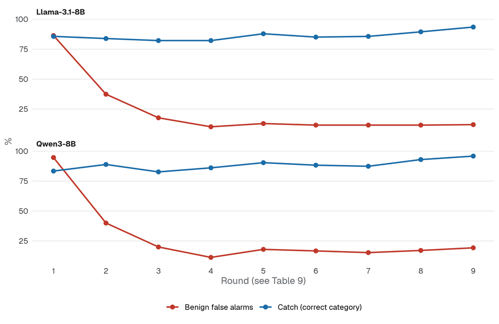

Figure 6. The 2-pass design on the two held-out generators across the rounds. Benign false alarms (red) and catch with the correct category (blue). Seed noise is 1-3 points on false alarms and up to 5 on catch with the precision rule, so small steps are not meaningful.

Table 9. Rounds plotted in Figure 6.

| Round | Change |
| --- | --- |
| 1 | Pilot thresholds (Horizon data only) |
| 2 | + Mistral/Gemma data, mixed validation |
| 3 | 2% budget (precision rule) |
| 4 | + safety benign scenes, Falcon3 validation |
| 5 | Greedy per-category rule, Phi/SmolLM3 validation |
| 6 | Cleaned data, retrain (round 4, greedy) |
| 7 | 3-seed mean (current data) |
| 8 | + educational hard negatives (3 seeds) |
| 9 | + friendly banter data (3 seeds) |

## 5.1 Lessons the rounds taught

1. **In-distribution numbers were inflated by generator similarity.** The pilot reported AUC 0.993-1.000 and about 1% false alarms; a different generator exposed 38% (8-question) and 86% (2-pass). Ranking transferred, operating points did not.
2. **Multi-generator training fixed most of the threshold shift** (86% to 37% false alarms for the 2-pass design) without hurting in-distribution results.
3. **A validation false-alarm budget is a floor, not a promise.** A 1.5-1.8% validation rate gave 3-24% on held-out generators. The gap shrinks only when validation includes generators the model has not seen *and* that write risky chats.
4. **Run-to-run noise is real.** Cleaning 0.5% of the training rows and retraining moved results as much as most differences between configurations. Over 3 seeds, false alarms vary by 1-3 points (sd) and catch with the precision rule by up to 5. The greedy rule is the stable one.
5. **More benign data is a weak lever for false alarms.** It raised the 2-pass design’s catch by 4-6 points, but did not reduce false alarms overall.
6. **Half of the remaining false alarms sit in one scene**: friends teasing each other (about 50% flagged for the 2-pass design). A blind audit of 46 of those rows found 43 friendly, 3 unclear and 0 cruel, so these are mostly real model errors. An earlier claim that this was label noise was wrong and has been corrected.
7. **Per-deployment calibration does not get to 2%.** Adding 100-400 labelled rows from the target traffic cut false alarms by 0-8 points, usually for about the same loss in recall. Some benign chats simply score like risky ones.
8. **A second-stage confirmer works but was dropped.** An offline cascade (Vigil flags, the 27B OpenJev model confirms) brought false alarms to 0.0-1.3% on all three sets, for a loss of 3-8 points of catch. It was dropped for licence (CC BY-NC 4.0) and cost reasons.

*Note on int8:* dynamic int8 ONNX quantization shrank the file only to 883 MB (the large multilingual embedding table stays fp32) and moved probabilities by up to 0.66, so it is not used.

# 6 Where each system is weak

## 6.1 Horizon

| Weakness | Evidence |
| --- | --- |
| **Collapses on unseen text for some categories** | Threats recall 88.5% on its own sample, 4.0% (Llama) and 5.0% (Qwen3). Grooming 77.0% to 36-58%. |
| **Malformed output** | 0.5% of rows unparseable on its own sample, 10% on Qwen3 (focus build), 17% for the baseline. |
| **False alarms on unseen text** | 20-21% of benign chats flagged (focus), 29% (baseline, Llama). |
| **Latency** | 747 ms p50 and 999 ms p95 on a CPU node; 3.6x Vigil’s. |
| **Memory** | 2,601 MiB peak against Vigil’s 2,018 MiB. |
| **No score to tune** | Horizon outputs categories, not probabilities. The only operating-point knob is retraining or prompt changes. |
| **Recorded results not reproducible here** | 90.36% grooming recall recorded; 70.1% measured for the baseline build on 2,000 of its own rows. |

## 6.2 Vigil

| Weakness | Evidence |
| --- | --- |
| **High false alarms on unseen text** | 11.6% (Llama), 17.1% (Qwen3) against a 2% target. At 1% real prevalence this means most flags are false (pilot estimate: 21-36% of flags real). |
| **Thresholds do not transfer across generators** | Fitted on validation data; false alarms 2-16x higher on held-out generators. |
| **Teasing banter** | About 50% of the “friends joking” scene is flagged, whatever data is added. |
| **Larger on disk than Horizon** | 1,231 MiB fp32; the multilingual embedding table dominates, and dynamic int8 does not help. |
| **Short context** | 1,024 tokens covers a message or short excerpt, not a long conversation. |
| **Severity is weak** | Macro-F1 0.63-0.67 in the pilot; generated severity labels are unreliable. |
| **Unproven multi-label behaviour** | Training data has at most one category per chat; the 2-pass soft-target path is untested. |
| **Not on a phone** | No Core ML or Android measurement exists. |
| **Lower precision on unseen sets** | Bullying precision 47%, threats 46-56%, grooming 55-66% on the held-out sets. |

## 6.3 What is true for both

- All test text is LLM-written, with labels set by construction. Real conversations are the deciding test.
- Both inherit label-quality problems from Horizon’s dataset (Horizon’s own analysis found weak grooming recall and missing patterns for bullying and personal info).
- The Llama and Qwen3 sets have 147-150 benign rows each, so false-alarm intervals are wide (about +-6 points).
- No overlap audit beyond exact matches: paraphrased templates between train and eval were not tested.

# 7 Improvements

Ordered by expected value against evidence, not by effort. Each item says what it fixes and what would confirm it worked. Items marked *untested* are hypotheses, not findings.

## 7.1 For Vigil

Table 10. Proposed improvements for Vigil.

| # | Improvement | What it fixes | How to confirm | Cost |
| --- | --- | --- | --- | --- |
| 1 | **Evaluate on real or human-written conversations** (even a few hundred, labelled by people), including real teasing and real grooming transcripts | Every number here rests on synthetic text. This is the only thing that can change a decision. | Same benchmark, same metric code, on the human set | High (data, consent, annotators) |
| 2 | **Choose the operating point as a product decision**, then ship two thresholds: a high-recall alert and a high-precision escalation | The data shows the curve; it cannot pick the point. Today’s single point is whatever the greedy rule produced. | Review a false-alarms-per-real-flag table with product and safety owners | Low |
| 3 | **Add a second-stage confirmer** with a permissive licence for chats Vigil flags | False alarms: the only thing that cut them to 0-1.3% (OpenJev cascade), for a 3-8 point loss in catch. Only flagged chats pay for it. | Offline cascade on saved scores first (cheap), then measure real latency and share of traffic forwarded | Medium |
| 4 | **Fix the teasing scene on the model side**: relabel or drop truly cruel rows, add human-written friendly banter, and try a contrastive loss for banter against bullying | About half of all remaining false alarms. More generated data did not move it (41-52%), so the generator text may not match real banter (*untested*). | Teasing-scene false alarms below 20% on both held-out generators, across 3 seeds | Medium |
| 5 | **Per-deployment threshold sets with upweighted deployment rows** | Threshold transfer. At weight 10 and 400 rows it halved false alarms in the best case but cost 9 points of catch. | Only worth it if the recall loss is acceptable; measure on a deployment sample | Low |
| 6 | **Shrink the model**: prune the vocabulary to English and Spanish, then distil to a smaller encoder | Disk. The multilingual embedding table is why int8 stays at 883 MB (*untested* that pruning removes most of it). | ONNX size and parity (max probability difference below 0.05) on the pruned model | Medium-high |
| 7 | **Measure on a phone**: Core ML on iOS and ONNX Runtime on Android | Spec phase 2. Server-CPU latency says little about devices. | p50 and p95 latency, memory and battery on two reference devices | Medium |
| 8 | **Window long conversations** instead of dropping overflow | 1,024-token ceiling; real chats are longer. | Recall on a long-conversation set (not yet built) | Medium |
| 9 | **Retrain severity on reliable labels** and add a multi-label training set | Severity macro-F1 0.63-0.67 and untested multi-label behaviour. | Severity macro-F1 on human labels; recall on chats with 2+ categories | Medium |
| 10 | **Standardise reporting**: 3 seeds, intervals, a held-out generator not used for any decision, and an overlap audit for near-duplicates | Round 4 showed that single runs mislead. | Report template and CI check | Low |

## 7.2 For Horizon

These come from where it fell short in this benchmark, and several can borrow from Vigil’s approach.

Table 11. Proposed improvements for Horizon.

| # | Improvement | What it fixes | How to confirm |
| --- | --- | --- | --- |
| 1 | **Constrained decoding** (a JSON grammar) or a structured-output head | 5-17% unparseable output on unseen text. These rows count as misses. | Unparseable rate of 0% on the same three sets |
| 2 | **Fix the threats category**: add hard negatives and unseen-style threats, and audit what the model outputs for threats on the held-out sets | Threats recall of 4-5% on unseen text is a failure, not noise. | Threats recall above 80% on Llama and Qwen3 |
| 3 | **Add a confidence score that can be thresholded**: read token probabilities of the category tokens | Horizon has one operating point and no way to trade recall for false alarms. | A recall/false-alarm curve with at least 3 usable points |
| 4 | **Train on more generators and report held-out ones**, as Vigil did | In-distribution results overstate performance. Vigil’s pilot fell from 1% to 38-86% false alarms on a new generator. | Held-out Llama and Qwen3 numbers beside the in-distribution ones |
| 5 | **Re-derive the recorded results with the shared metric code** | The recorded 90.36% grooming recall was not reproduced (70.1% for the baseline build). | A reconciliation note naming the protocol differences |
| 6 | **Add a pre-filter for the easy majority** (benign chats), for example a small encoder in front of the LLM | Latency and energy: 747 ms p50 for every chat, including the obviously benign ones. | Share of chats skipped and end-to-end p50 |
| 7 | **Consider Vigil as the first stage** and keep Horizon for flagged chats where generated explanations are wanted | Combines Vigil’s recall and speed with Horizon’s flexibility. | Offline cascade on saved outputs, then device cost |

## 7.3 A combined system

The two are more complementary than competing, and the evidence suggests a three-tier shape:

1. **Vigil on every chat**, on the device or the nearest server: one pass, 207 ms on a CPU node, 99% any-flag recall.
2. **A confirmer on flagged chats only**: Horizon (already on devices), or a permissively licensed model if a stronger one is needed.
3. **Human review** of confirmed high-severity flags.

This is not tested end to end. What exists is an offline cascade of Vigil with a third model (OpenJev: 0.0-1.3% false alarms) and the benchmark above. The first experiment is the same offline cascade with Horizon as the confirmer, using the saved benchmark outputs, which costs no new compute.

# 8 Decision guide

Table 12. Which system for which priority.

| If you care most about… | Choose | Because |
| --- | --- | --- |
| Catching risky chats, especially threats and grooming, on unseen text | Vigil | +21.7 / +30.4 points of catch on held-out generators; threats 86-99% against 4-5% |
| Speed on a server CPU | Vigil | 207 ms against 747 ms median |
| Smallest download | Horizon | 1,017 MiB against 1,231 MiB (fp32 Vigil) |
| A proven on-device path today | Horizon | LiteRT-LM INT8 export exists; Vigil has no phone measurement |
| Fewest false alarms on its own data | Horizon (focus) | 0.4% against 0.9%, but the difference is a handful of rows |
| Fewest false alarms on unseen text | Neither | Both flag 12-21%; only a confirmer got below 2% |
| Never emitting malformed output | Vigil | It returns numbers, not text |
| Explanations in text | Horizon | It is generative; Vigil is not |

> **Bottom line.** On the evidence collected, Vigil is the stronger detector and the faster one, and Horizon is the smaller and more deployable one today. Neither has been measured on real conversations or on a phone, and neither reaches the false-alarm target on text it has not seen. The next evidence that changes this picture is a human-written test set and an on-device measurement, not another round of tuning on synthetic data.

# 9 Sources

- **Head-to-head benchmark (2026-09-30):** per-set, per-seed and per-category counts, plus latency, disk and memory, from one run on an exclusive 8-CPU node. All accuracy and speed tables and Figures 1-5 come from it.
- **Vigil’s development rounds:** the written results of each round (pilot, cross-generator test, mixed training, false-alarm budget, rounds 2-4, seeds and hard negatives, friendly banter, per-deployment calibration). Figure 6 is typed in from these and is not part of the benchmark data.
- **OpenJev cascade:** the zero-shot baseline and offline cascade results on a separate branch.
- **Design and targets:** Vigil’s design specification of 2026-09-29.
- **Horizon:** its current README and the benchmark above. An earlier research paper in its repository describes a MobileBERT design that the Gemma 3 1B build replaced; it was not used for any number.

If a later round changes the figures in *How Vigil got here*, update the `journey` table in the source file’s data chunk.

Rendered with R version 4.6.1 (2026-06-24)

SafeCircle research · Vigil vs Horizon · 2026-10-01

[figure not shown]